# CT0429 - Analisi Predittiva - aa 21/22 - Appello I

# Istruzioni

Salvate questo file con il nome `matricola.Rmd`. Questo sarà il file che dovrete consegnare. Il file deve compilare senza problemi: files che non possono essere compilati correttamente saranno penalizzati.

Per essere sicuri di poter trovare il file al momento della consegna potete controllare dove è il file quando compilate il file la prima volta usando il comando `getwd()`.

```r
getwd()
```

```
## [1] "C:/Users/PayThePizzo/Projects/PredictiveAnalysisNotes/Exams/11_Jan_2022"
```

```r
## da cancellare quando siete sicuri di dove è il file
```

Attenzione - per tutto l’esame, se non specificato esplicitamente, il livello di significatività da usare è $\alpha = 0.02$

# Esercizio 1

Il data-scientist di un’azienda che produce app ludiche per cellulari vuole costruire un modello predittivo per il tempo in cui gli utenti hanno usato l’app. Dal dataset disponibile estrae i records delle persone che, nel periodo di Gennaio-Marzo 2021 hanno dichiarato al momento dell’iscrizione di voler condividere con l’azienda l’informazione sulla loro età: questo identifica 70 utenti per cui sono disponibili le seguenti informazioni:

- `numAccess`: il numero totale di accessi eseguiti all’app dall’utente nell’anno 2021
- `age`: l’età dichiarata dall’utente
- `time`: il tempo passato dall’utente usando l’app

La variabile `time` è la variabile di interesse (variabile risposta).

Tutte le informazioni a disposizione dell’analista sono disponibili nel dataset `dex1` che si può caricare usando il seguente codice:

```r
dex1 <- read.csv("ex1_data.csv", header = TRUE)
```

### Es. 1.a

Si costruisca un primo modello `fit1` in cui le variabili `age` e `numAccess` sono usate come predittori. Si stimi il modello `fit1` commentando la sua significatività.

Il specificato e’:

$$time = \beta_{0} + \beta_{1}age +
\beta_{2}numAccess$$

```r
fit1 <- lm(time ~ age + numAccess, data = dex1)
summary(fit1)
```

```
##
## Call:
## lm(formula = time ~ age + numAccess, data = dex1)
##
## Residuals:
##     Min      1Q  Median      3Q     Max
## -515.80 -111.54    8.45  135.21  874.33
##
## Coefficients:
##             Estimate Std. Error t value Pr(>|t|)
## (Intercept) 113.0697   102.7900   1.100    0.275
## age           0.2045     2.2421   0.091    0.928
## numAccess    24.8515     0.8375  29.673   <2e-16 ***
## ---
## Signif. codes:  0 '***' 0.001 '**' 0.01 '*' 0.05 '.' 0.1 ' ' 1
##
## Residual standard error: 243 on 67 degrees of freedom
## Multiple R-squared:  0.9293, Adjusted R-squared:  0.9272
## F-statistic: 440.3 on 2 and 67 DF,  p-value: < 2.2e-16
```

Nel `summary` del modello troviamo un valore particolarmente alto dell’ $R^{2}$ e della F-statistic, per un p-value molto piccolo. Percio’, il modello sembra essere particolarmente significativo.

### Es. 1.b

Si costruisca un modello `fit2` in cui solo la variabile `numAccess` è usata come predittore

```r
fit2 <- lm(time ~ numAccess, data=dex1)
summary(fit2)
```

```
##
## Call:
## lm(formula = time ~ numAccess, data = dex1)
##
## Residuals:
##     Min      1Q  Median      3Q     Max
## -516.08 -110.40    8.58  138.02  874.46
##
## Coefficients:
##             Estimate Std. Error t value Pr(>|t|)
## (Intercept) 121.5206    44.1763   2.751  0.00761 **
## numAccess    24.8519     0.8314  29.893  < 2e-16 ***
## ---
## Signif. codes:  0 '***' 0.001 '**' 0.01 '*' 0.05 '.' 0.1 ' ' 1
##
## Residual standard error: 241.2 on 68 degrees of freedom
## Multiple R-squared:  0.9293, Adjusted R-squared:  0.9282
## F-statistic: 893.6 on 1 and 68 DF,  p-value: < 2.2e-16
```

Si verifichi tramite una verifica di ipotesi se il modello `fit2` risulta significativo rispetto al modello `fit1`. Si scriva in forma esplicita l’ipotesi nulla e alternativa che si stanno verificando tramite il test indicando infine se è possibile rifiutare l’ipotesi nulla.

Essendo i due modelli, nested-models possiamo scrivere le ipotesi nella seguente maniera:

- $H_{0}: age = 0 \rightarrow time = \beta_{0} + (\beta_{1}age \times 0) + \beta_{2}numAccess$
  - Il predittore `age` non mostra una relazione lineare rilevante con la variabile risposta
- $H_{A}: age \neq 0 \rightarrow time = \beta_{0} + \beta_{1}age + \beta_{2}numAccess$
  - Il predittor `age` mostra una relazione lineare rilevante con la variabile risposta

Otteniamo la statistica test tramite:

$$\frac{\widehat{\beta}_{j} -
\beta_{j}^{*}}{SE[\widehat{\beta}_{j}]} \sim t_{n-p}
\left\{ \begin{array}{rcl}
H_{0}: \beta_{j} = \beta_{j}^{*} \\
H_{A}: \beta_{j} \neq \beta_{j}^{*}
\end{array}\right.$$

```r
# t_obs
t_obs<-(coefficients(fit1)[2]-0)/summary(fit1)$coef[2,2]
t_obs
```

```
##        age
## 0.09120601
```

```r
# p-value
2*pt(abs(t_obs), df.residual(fit1), lower.tail = FALSE )
```

```
##      age
## 0.927601
```

Considerando un intervallo di confidenza al livello di significativita’ del 98%, confermiamo che il valore `0` cade all’interno dello stesso:

```r
# Confidence Intervals
confint(fit1, level=0.98)[2,]
```

```
##       1 %      99 %
## -5.139120  5.548106
```

### Es. 1.c

Usando il modello `fit2` si calcolino degli intervalli di confidenza e di predizione per degli utenti che compiano 60 e 200 accessi. Si commenti l’ampiezza degli intervalli ottenuti e si spieghi brevemente la differenza tra intervallo di confidenza e di predizione.

Calcoliamo l’intervallo di confidenza

```r
nd <- data.frame(numAccess=c(60,200))

ci_vals <- predict(fit2, newdata=nd, interval="confidence", level = 0.98)
ci_vals
```

```
##        fit      lwr      upr
## 1 1612.636 1533.590 1691.682
## 2 5091.906 4768.134 5415.678
```

```r
ci_vals[,3]-ci_vals[,2]
```

```
##        1        2
## 158.0922 647.5440
```

Calcoliamo l’intervallo di predizione

```r
pi_vals <- predict(fit2, newdata=nd, interval="prediction", level = 0.98)
pi_vals
```

```
##        fit      lwr      upr
## 1 1612.636 1032.474 2192.798
## 2 5091.906 4432.233 5751.578
```

```r
pi_vals[,3]-pi_vals[,2]
```

```
##        1        2
## 1160.324 1319.345
```

Nell’intervallo di confidenza, ci interessiamo all’incertezza intorno a $\mathbb{E}[\hat{y}(x_{0})]$, ovvero rispetto ai tipici valori che un predittore $x_{0}$ assume. Normalmente si utilizzano per valori che sono nel range dei valori osservati. Al contrario, nell’intervallo di predizione ci concentriamo sull’incertezza intorno a $Y_{0}$ una nuova osservazione di $Y$ dato il predittore $x_{0}$ e questo aumenta la variabilita’ della stima, aumentando anche l’ampiezza dell’intervallo di predizione.

### Es. 1.d

Si commenti sulla generalizzabilità dell’analisi svolta dal data scientist per tutti gli utenti dell’app (suggerimento: si rilegga attentamente l’introduzione dell’esercizio in cui viene presentato il dataset).

Essendo il dataset limitato a dati del periodo “Gennaio-Marzo 2021”, sarebbe difficile dire che il campione sia ben generalizzato, dal momento che i mesi invernali tendono ad essere quelli in cui si tende a stare al chiuso e quindi ad utilizzare di piu’ i dispositivi mobili. Inoltre l’eta’ e’ stata dichiarata al momento dell’iscrizione e senza verifiche, il che puo’ portare a pensare che ci possano essere svariate istanze di persone che abbiano dichiarato il falso. Per quanto riguarda gli utenti, un campione di 70 utenti volontari, restringe i dati alle persone che hanno deciso di condividere le informazioni ed e’ lontano da un tipico campione randomizzato della popolazione con la conseguenza di poter essere poco rappresentativo. Infine, le variabili esplicative raccolte sono poche ed e’ difficile ottimizzare un modello, quando (come si e’ dimostrato sopra) una delle due variabili esplicative e’ statisticamente poco rilevante.

# Esercizio 2

Il gestore di un sistema di rete mantiene un registro di informazioni varie in cui registra anche se in una giornata si sono registrati guasti che richiedono l’intervento di un operatore esterno per ripristinare il sistema. Il file `ex2_data.csv` contiene le seguenti variabili:

- `numAccess`: il numero di accessi alla rete
- `numRequests`: il numero di richieste gestite dalla rete
- `durationMean`: la durata media di una sessione di un utente
- `durationMax`: la durata massima di una sessione di un utente
- `durationMin`: la durata minima di una sessione di un utente
- `fail`: un indicatore che ha valore 1 quando si è registrato un guasto che richiede l’intervento di un operatore esterno per ripristinare il sistema

Si carichi il dataset usando il codice seguente:

```r
dex2 <- read.csv("ex2_data.csv", header = TRUE)
```

Si desidera costruire un modello predittivo per la variabile `fail`, un modello cioè che predica se in un giorno sarà necessario l’intervento di un operatore esterno per ripristinare il sistema.

### Es. 2.a

Si stimi il modello `fitTot`, un modello lineare generalizzato in cui tutti predittori sono inseriti nel modello e la variabile risposta è l’indicatore di un guasto (`fail`): si usi la distribuzione Binomiale con legame canonico. Si commenti l’effetto stimato delle variabili `numAccess` e `numRequests`

```r
fitTot <- glm(fail ~ ., family=binomial(link="logit"), data=dex2)

summary(fitTot)
```

```
##
## Call:
## glm(formula = fail ~ ., family = binomial(link = "logit"), data = dex2)
##
## Deviance Residuals:
##     Min       1Q   Median       3Q      Max
## -2.5195  -0.5909  -0.1861   0.6047   2.3591
##
## Coefficients:
##                Estimate Std. Error z value Pr(>|z|)
## (Intercept)  -5.901e+00  1.805e+00  -3.269 0.001080 **
## numAccess     7.528e-04  7.142e-05  10.541  < 2e-16 ***
## numRequests  -1.728e-04  1.086e-04  -1.591 0.111690
## durationMean  6.200e-02  1.610e-02   3.851 0.000118 ***
## durationMax   6.959e-03  1.872e-02   0.372 0.710041
## durationMin   3.834e-02  4.791e-02   0.800 0.423539
## ---
## Signif. codes:  0 '***' 0.001 '**' 0.01 '*' 0.05 '.' 0.1 ' ' 1
##
## (Dispersion parameter for binomial family taken to be 1)
##
##     Null deviance: 619.12  on 449  degrees of freedom
## Residual deviance: 369.09  on 444  degrees of freedom
## AIC: 381.09
##
## Number of Fisher Scoring iterations: 5
```

L’effetto dei predittori, in questo contesto puo’ essere interpretato come l’effetto che un particolare preditore ha sul log-odd-ratio, assumendo che tutti gli altri predittori abbiano valori fissati.

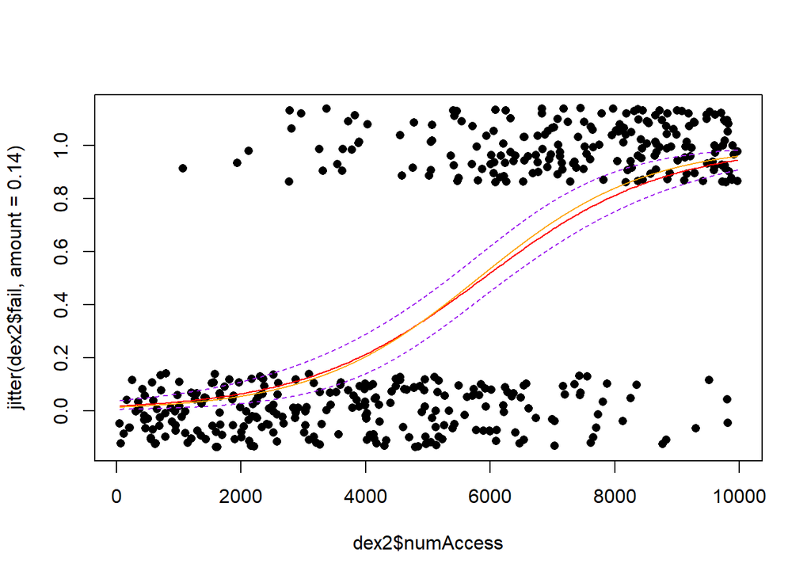

```r
plot(dex2$numAccess, jitter(dex2$fail, amount = 0.14), pch = 16)

# GLM with 1 predictor
fit_numAccess <- glm(fail ~ numAccess, family=binomial, data=dex2)

# "pure" numAccess effect
lines(sort(dex2$numAccess),
      predict(fit_numAccess, newdata = data.frame(numAccess = sort(dex2$numAccess)), type = "response"),
      col = "red")

# Fix the values
nd <- data.frame(numAccess = seq(min(dex2$numAccess), max(dex2$numAccess)),
                 numRequests = median(dex2$numRequests),
                 durationMean = median(dex2$durationMean),
                 durationMax = median(dex2$durationMax),
                 durationMin = median(dex2$durationMin))

# numAccess effect, given that all the predictors have median values
lines(sort(nd$numAccess),
      predict(fitTot, newdata = nd,
             type = "response"), col = "orange")

# Uncertainty estimation

# fit, se.fit
linpred <- predict(fitTot, newdata = nd,
             type = "link", se.fit = TRUE)

# confidence intervals for the linear predictor
# upper and lower bound
cint <- cbind(linpred$fit - qnorm(.995) * linpred$se.fit,
              linpred$fit + qnorm(.995) * linpred$se.fit)

# two columns of values between 0 and 1
cint_response <-  binomial()$linkinv(
    cbind(linpred$fit - qnorm(.995) * linpred$se.fit,
          linpred$fit + qnorm(.995) * linpred$se.fit))

lines(sort(nd$numAccess), cint_response[,1], lty = 2, col = "purple")
lines(sort(nd$numAccess), cint_response[,2], lty = 2, col = "purple")
```

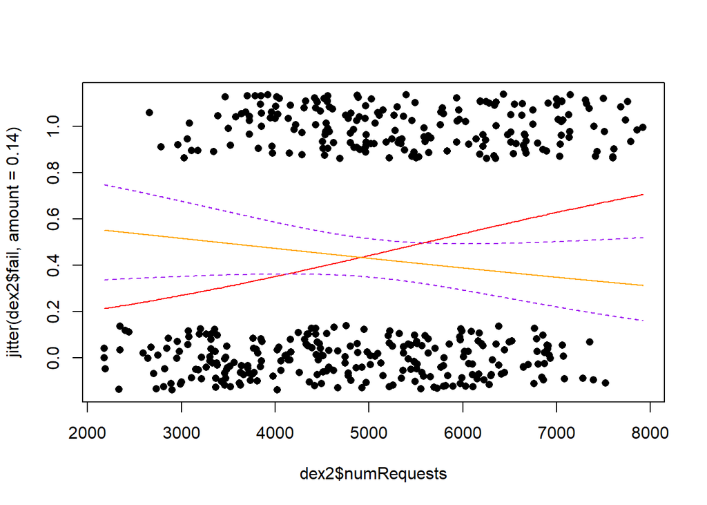

```r
plot(dex2$numRequests, jitter(dex2$fail, amount = 0.14), pch = 16)

# GLM with 1 predictor
fit_numRequests <- glm(fail ~ numRequests, family=binomial, data=dex2)

# "pure" numAccess effect
lines(sort(dex2$numRequests),
      predict(fit_numRequests, newdata = data.frame(numRequests = sort(dex2$numRequests)), type = "response"),
      col = "red")

# Fix the values
nd <- data.frame(numRequests = seq(min(dex2$numRequests), max(dex2$numRequests)),
                 numAccess = median(dex2$numAccess),
                 durationMean = median(dex2$durationMean),
                 durationMax = median(dex2$durationMax),
                 durationMin = median(dex2$durationMin))

# numAccess effect, given that all the predictors have median values
lines(sort(nd$numRequests),
      predict(fitTot, newdata = nd,
             type = "response"), col = "orange")

# Uncertainty estimation

# fit, se.fit
linpred <- predict(fitTot, newdata = nd,
             type = "link", se.fit = TRUE)

# confidence intervals for the linear predictor
# upper and lower bound
cint <- cbind(linpred$fit - qnorm(.995) * linpred$se.fit,
              linpred$fit + qnorm(.995) * linpred$se.fit)

# two columns of values between 0 and 1
cint_response <-  binomial()$linkinv(
    cbind(linpred$fit - qnorm(.995) * linpred$se.fit,
          linpred$fit + qnorm(.995) * linpred$se.fit))

lines(sort(nd$numRequests), cint_response[,1], lty = 2, col = "purple")
lines(sort(nd$numRequests), cint_response[,2], lty = 2, col = "purple")
```

### Es. 2.b

Usando un approccio backward si parta dal modello `fitTot` per individuare dei modelli che risultino in qualche senso ottimali. Si utilizzi sia AIC che BIC per l’individuazione di questo modello ottimale. Si nota una qualche differenza nella scelta effettuata usando i due criteri? Si commenti il risultato della selezione delineando le differenze tra i due criteri.

```r
# AIC
fitTot_AIC <- step(fitTot, direction = "backward", trace=-1, k=2)
```

```
## Start:  AIC=381.09
## fail ~ numAccess + numRequests + durationMean + durationMax +
##     durationMin
##
##                Df Deviance    AIC
## - durationMax   1   369.23 379.23
## - durationMin   1   369.73 379.73
## <none>              369.09 381.09
## - numRequests   1   371.65 381.65
## - durationMean  1   384.86 394.86
## - numAccess     1   572.26 582.26
##
## Step:  AIC=379.23
## fail ~ numAccess + numRequests + durationMean + durationMin
##
##                Df Deviance    AIC
## - durationMin   1   369.86 377.86
## <none>              369.23 379.23
## - numRequests   1   371.79 379.79
## - durationMean  1   385.67 393.67
## - numAccess     1   572.59 580.59
##
## Step:  AIC=377.86
## fail ~ numAccess + numRequests + durationMean
##
##                Df Deviance    AIC
## <none>              369.86 377.86
## - numRequests   1   372.69 378.69
## - durationMean  1   386.87 392.87
## - numAccess     1   573.34 579.34
```

```r
# BIC
fitTot_BIC <- step(fitTot, direction = "backward", trace=-1, k=log(nrow(dex2)))
```

```
## Start:  AIC=405.75
## fail ~ numAccess + numRequests + durationMean + durationMax +
##     durationMin
##
##                Df Deviance    AIC
## - durationMax   1   369.23 399.77
## - durationMin   1   369.73 400.28
## - numRequests   1   371.65 402.19
## <none>              369.09 405.75
## - durationMean  1   384.86 415.41
## - numAccess     1   572.26 602.81
##
## Step:  AIC=399.77
## fail ~ numAccess + numRequests + durationMean + durationMin
##
##                Df Deviance    AIC
## - durationMin   1   369.86 394.30
## - numRequests   1   371.79 396.23
## <none>              369.23 399.77
## - durationMean  1   385.67 410.10
## - numAccess     1   572.59 597.02
##
## Step:  AIC=394.3
## fail ~ numAccess + numRequests + durationMean
##
##                Df Deviance    AIC
## - numRequests   1   372.69 391.02
## <none>              369.86 394.30
## - durationMean  1   386.87 405.20
## - numAccess     1   573.34 591.67
##
## Step:  AIC=391.02
## fail ~ numAccess + durationMean
##
##                Df Deviance    AIC
## <none>              372.69 391.02
## - durationMean  1   388.98 401.20
## - numAccess     1   598.32 610.54
```

```r
fitTot_AIC$call
```

```
## glm(formula = fail ~ numAccess + numRequests + durationMean,
##     family = binomial(link = "logit"), data = dex2)
```

```r
fitTot_BIC$call
```

```
## glm(formula = fail ~ numAccess + durationMean, family = binomial(link = "logit"),
##     data = dex2)
```

AIC e BIC sono Information Criteria, misure di bonta’ del modello che tengono in considerazione il numero di parametri stimati e che penalizzano i modelli sovra-parametrizzati. In particolare AIC viene utilizzato quando `n` e’ grande, mentre BIC favorisce i modelli parsimoniosi.

Infatti lo step decisivo, nella BIC Backward Selection, evidenza che il miglioramento del punteggio, di soli tre punti, non porta un grande vantaggio rispetto a tenere la variabile `numRequests` all’interno del modello. Il metodo AIC Backward Selection invece, tende a conservarlo.

```r
# AIC
c(fitTot_AIC$deviance, fitTot_AIC$null.deviance, fitTot_AIC$aic)
```

```
## [1] 369.8613 619.1220 377.8613
```

```r
# BIC
c(fitTot_BIC$deviance, fitTot_BIC$null.deviance, fitTot_BIC$aic)
```

```
## [1] 372.6943 619.1220 378.6943
```

Infine, considerando che `numRequests` non e’ un parametro statisticamente rilevante, e’ preferibile il modello `fitTot_BIC`.

### Es. 2.c

Usando il modello `fitTot`, si stimi la probabilità che si registri un guasto in due giornate con valori dei predittori pari a quelli contenuti nel dataset `nd` specificato più in basso.

Si produca anche una stima intervallare per la probabilità usando un livello di confidenza pari al 95%.

```r
nd <- data.frame(numAccess = c(10,5290),
                 numRequests = c(2000,5000),
                 durationMean = c(10,24.8),
                 durationMax = c(75,90),
                 durationMin = c(9,5))
rownames(nd) <- c("day1","day2")

rpred <- predict(fitTot, type = "response", newdata = nd, level=0.95)
```

### Es. 2.d

Usando il modello `fitTot` si predica per ogni giornata del dataset `dex2` se ci si aspetta che avvenga un guasto. Per definire se per una giornata viene predetto un guasto si usi un livello di probabilità pari a 0.5, cioè si definisce che per una giornata viene predetto l’evento `guasto` se la la probabilità che ci sia un guasto è > 0.5. Si verifichi la proporzione di predizioni corrette e sbagliate prodotte dal modello.